# Lesson3: Data Wrangling Basics

2019-10-25

## Outline

- Loading and inspecting data
- Working with vectors
- Working with matrices
- Working with dataframes (the old way)

## Basics of data formats

- Data are typically stored as text files
- Different ‘rows’ of data appear on different lines
- Values for a given ‘row’ are typically separated by either a comma, or a tab

Comma-separated values (.csv)

```r
name,age,member_since
bob,20,2015
frank,40,2015
tammy,15,2016
```

Tab-separated values (.tsv or .txt)

```r
name  age  member_since
bob  20  2015
frank  40  2015
tammy  15  2016
```

## Loading data into R

| Data type | Extension | Function | Package |
| --- | --- | --- | --- |
| Comma separated values | csv | `read.csv()` | utils (default) |
|  |  | `read_csv()` | readr (tidyverse) |
| Tab separated values | tsv | `read_tsv()` | readr |
| Other delimited formats | txt | `read.table()` | utils |
|  |  | `read_table()` | readr |
|  |  | `read_delim()` | readr |
| Excel | xlsx, xls | `read_excel()` | readxl (tidyverse) |

## Which read function should I use? (old)

- For reading data tables use:
  - `read_csv`/`read_tsv` from the `readr` package (`tidyverse`)
  - This avoids some very annoying default R behavior (changing names, making strings into factors)
- For reading matrices, use:
  - `read.csv`/`read.table` (baseR)
  - This allows you to use rownames, which are very useful for working with matrices

## Which read function should I use? (new)

- Always use `read_csv`/`read_tsv` from the `readr` package (`tidyverse`)
- For reading matrices, use the function `column_to_rownames` to specify which column should be treated as rownames

## Specifying where a file ‘is’

- Relative and absolute file ‘paths’

```r
getwd()
```

```
## [1] "/Users/jmmcfarl/BootCamp/R_BootCamp_2019_master/Lessons"
```

- Organize project with a ‘data’ folder for data.
- Use the `here` function to specify the file path.

```r
imported_data <- read_csv("/Users/jmmcfarl/BootCamp/R_BootCamp_2019/
                          data/data_file.csv")
```

```r
imported_data <- read_csv(here::here('data', 'data_file.csv')
```

## For example

Load a tab-delimited table of metadata

```r
my_table <- read_tsv(here::here('data', 'my_metadata_table.tsv'))
```

Load the second sheet from an xlsx file

```r
my_table <- read_excel(here::here('data', 'my_metadata_file.xlsx'), sheet = 2)
```

## Loading matrices

```r
counts_matrix <-  read_tsv(here::here('data', 'normalized_counts.txt'))
corner(counts_matrix)
```

```
## # A tibble: 5 x 5
##   X1          Mov10_kd_2 Mov10_kd_3 Mov10_oe_1 Mov10_oe_2
##   <chr>            <dbl>      <dbl>      <dbl>      <dbl>
## 1 1/2-SBSRNA4       36.4      43.8      53.3         49.1
## 2 A1BG              45.4      42.8      83.2         72.3
## 3 A1BG-AS1         164.      189.      183.         169.
## 4 A1CF               0         1.07      0.832        0
## 5 A2LD1             93.3      86.6     115.         112.
```

```r
counts_matrix <- column_to_rownames(counts_matrix, var = 'X1')
corner(counts_matrix)
```

```
##             Mov10_kd_2 Mov10_kd_3 Mov10_oe_1 Mov10_oe_2 Mov10_oe_3
## 1/2-SBSRNA4   36.42934  43.842016  53.261952   49.08123   58.14855
## A1BG          45.37690  42.772698  83.221799   72.28327   62.73922
## A1BG-AS1     163.61248 189.269189 183.087958  168.66097  163.73407
## A1CF           0.00000   1.069317   0.832218    0.00000    0.00000
## A2LD1         93.31024  86.614714 114.846083  111.54826   79.57170
```

## Inspecting data

- Always start with some quick inspection of data after reading it into R
- Check for:
  - Column (always) and row (matrix only) names are correct
  - Make sure data types of columns are correct
- Dataframe:
  - `View(df)`: Open spreadsheet viewer
  - `head(df)`: Show top K (10) rows
  - `glimpse(df)`: quick overview of a table
- Matrix:
  - `useful::corner(mat)`: Show upper left corner of matrix
  - `dim(mat)`: Number of rows and columns
  - `rownames(mat)`/`colnames(mat)`: extract row/column names

**Practice**

## Backup plan

- Importing files using the RStudio `Import Dataset` tool.

## Accessing data? Let’s start with a vector

```r
age <- c(15, 22, 45, 52, 73, 81)
```

```r
age[5]
```

```
## [1] 73
```

```r
idx <- c(3,5,6) # create vector of the elements of interest
age[idx]
```

```
## [1] 45 73 81
```

## Selecting elements with logical statements

| Operator | Description |
| --- | --- |
| > | greater than |
| >= | greater than or equal to |
| < | less than |
| <= | less than or equal to |
| == | equal to |
| != | not equal to |
| & | and |
| \| | or |

```r
age > 50
```

```
## [1] FALSE FALSE FALSE  TRUE  TRUE  TRUE
```

```r
log_idx <- age > 50
age[log_idx]
```

```
## [1] 52 73 81
```

```r
#same as age[age > 50]
```

```r
age == 52
```

```
## [1] FALSE FALSE FALSE  TRUE FALSE FALSE
```

```r
age[age == 52]
```

```
## [1] 52
```

```r
age[age != 52]
```

```
## [1] 15 22 45 73 81
```

## Subsetting using names

```r
age <- c(Allice = 15, Bob = 22, Charlie = 45, Dan = 52)
age
```

```
##  Allice     Bob Charlie     Dan
##      15      22      45      52
```

```r
names(age)
```

```
## [1] "Allice"  "Bob"     "Charlie" "Dan"
```

```r
age[c('Bob', 'Charlie')]
```

```
##     Bob Charlie
##      22      45
```

- Most useful when working with lists (more to come)

## Brief asside on NULL

R has another special value `NULL` which represents ‘the absence of a value’.

For example

```r
my_vec <- c(1,2,3)
names(my_vec)
```

[output not shown]

Note: Subtly different from `NA`, but don’t worry about that now.

## Reordering data

```r
x <- c(4, 2, 3, 5, 1)
sort(x)
```

```
## [1] 1 2 3 4 5
```

- Or in decreasing order

```r
sort(x, decreasing = TRUE)
```

```
## [1] 5 4 3 2 1
```

## Reordering using indexing

- Indexing can also be used to reorder data

```r
teaching_team <- c("Mary", "Meeta", "Radhika")
```

```r
reorder_teach <- teaching_team[c(3, 1, 2)] # Saving the results to a variable
reorder_teach
```

```
## [1] "Radhika" "Mary"    "Meeta"
```

**Practice**

## Subsetting matrices

- Same as subsetting vectors, but can be applied to both rows and columns!
- General formula:

```r
matrix[row_set, column_set]
```

- `row_set` and `column_set` can be individual elements or vectors
- Leave either blank if you want all rows/columns, e.g.:

```r
matrix[row_set, ]
matrix[, column_set]
```

## Matrix subsetting examples

```r
counts_mat <- read_csv(here::here('data', 'counts_rpkm.csv'))
counts_mat <- column_to_rownames(counts_mat, var = 'X1')
useful::corner(counts_mat)
```

```
##                      sample2    sample5 sample7   sample8   sample9
## ENSMUSG00000000001 19.265000 23.7222000 2.61161 5.8495400 6.5126300
## ENSMUSG00000000003  0.000000  0.0000000 0.00000 0.0000000 0.0000000
## ENSMUSG00000000028  1.032290  0.8269540 1.13441 0.6987540 0.9251170
## ENSMUSG00000000031  0.000000  0.0000000 0.00000 0.0298449 0.0597726
## ENSMUSG00000000037  0.056033  0.0473238 0.00000 0.0685938 0.0494147
```

- ‘Slice’ out one row

```r
counts_mat[3, ]
```

```
##                    sample2  sample5 sample7  sample8  sample9  sample4
## ENSMUSG00000000028 1.03229 0.826954 1.13441 0.698754 0.925117 0.827891
##                    sample6 sample12  sample3 sample11 sample10  sample1
## ENSMUSG00000000028 1.16863 0.673563 0.892183 0.975327  1.04592 0.937792
```

- Or slice out a single column

```r
counts_mat[, 3]
```

```
##     [1]  2.611610e+00  0.000000e+00  1.134410e+00  0.000000e+00
##     [5]  0.000000e+00  2.523420e-01  7.394900e+00  1.139850e+00
##     [9]  9.940560e+00  1.137210e+01  2.528090e+02  1.769000e+00
##    [13]  0.000000e+00  0.000000e+00  5.223460e+01  0.000000e+00
##    [17]  6.370100e-01  3.041450e+00  4.892800e+01  6.086450e+00
##    [21]  1.086380e+00  8.182740e-01  7.856230e+00  2.841230e+00
##    [25]  0.000000e+00  5.174530e-08  2.537220e-01  3.016890e+01
##    [29]  7.504530e+01  2.011190e-02  0.000000e+00  9.293820e-02
##    [33]  7.782640e+00  4.432830e+00  7.268310e-02  0.000000e+00
##    [37]  8.595270e-01  0.000000e+00  1.951990e-02  2.771790e+00
##    [41]  0.000000e+00  8.982420e-02  0.000000e+00  1.355550e+01
##    [45]  0.000000e+00  4.418390e+00  7.672120e-01  3.619680e+00
##    [49]  7.088300e+00  4.039600e+00  0.000000e+00  1.012400e+01
##    [53]  2.878000e-01  2.714030e+00  8.279740e+00  7.860010e-01
##    [57]  6.558450e+02  3.637120e-02  0.000000e+00  2.997320e-02
```

[output cut: 9692 more lines]

- Slice a set of rows and set of columns

```r
counts_mat[1:4, 2:3]
```

```
##                      sample5 sample7
## ENSMUSG00000000001 23.722200 2.61161
## ENSMUSG00000000003  0.000000 0.00000
## ENSMUSG00000000028  0.826954 1.13441
## ENSMUSG00000000031  0.000000 0.00000
```

## Using rownames and column names

- Use `colnames(mat)` and `rownames(mat)` to get the column and rownames of a matrix.
- Data for a list of rows (genes)

```r
counts_mat[c('ENSMUSG00000000028', 'ENSMUSG00000000037'), ]
```

```
##                     sample2   sample5 sample7   sample8   sample9  sample4
## ENSMUSG00000000028 1.032290 0.8269540 1.13441 0.6987540 0.9251170 0.827891
## ENSMUSG00000000037 0.056033 0.0473238 0.00000 0.0685938 0.0494147 0.180883
##                     sample6  sample12  sample3  sample11 sample10  sample1
## ENSMUSG00000000028 1.168630 0.6735630 0.892183 0.9753270 1.045920 0.937792
## ENSMUSG00000000037 0.143884 0.0662324 0.146196 0.0206405 0.017004 0.151417
```

- Specifying columns and rows by name

```r
counts_mat['ENSMUSG00000000001', c('sample7', 'sample5')]
```

```
##                    sample7 sample5
## ENSMUSG00000000001 2.61161 23.7222
```

## The %in% operator

- Check whether each element of vector1 is contained in the set vector2

```r
A <- c(1, 2, 3, 4)
B <- c(3, 4, 5, 6)

A %in% B
```

```
## [1] FALSE FALSE  TRUE  TRUE
```

## Applications of %in%

- Useful for restricting to the intersection of elements in two lists

```r
A <- c(1, 2, 3, 4)
B <- c(3, 4, 5, 6)

A[A %in% B]
```

```
## [1] 3 4
```

- Or checking whether any/all elements of A are contained in B

```r
any(A %in% B)
```

```
## [1] TRUE
```

```r
all(A %in% B)
```

```
## [1] FALSE
```

## Other ‘set’ functions

- `intersect(A, B)`: return the elements in both `A` and `B`
- `setdiff(A, B)`: return the elements in `A` that are not in `B`
- `union(A, B)`: return the elements in either `A` or `B`

**Practice**

## Inspecting data visually

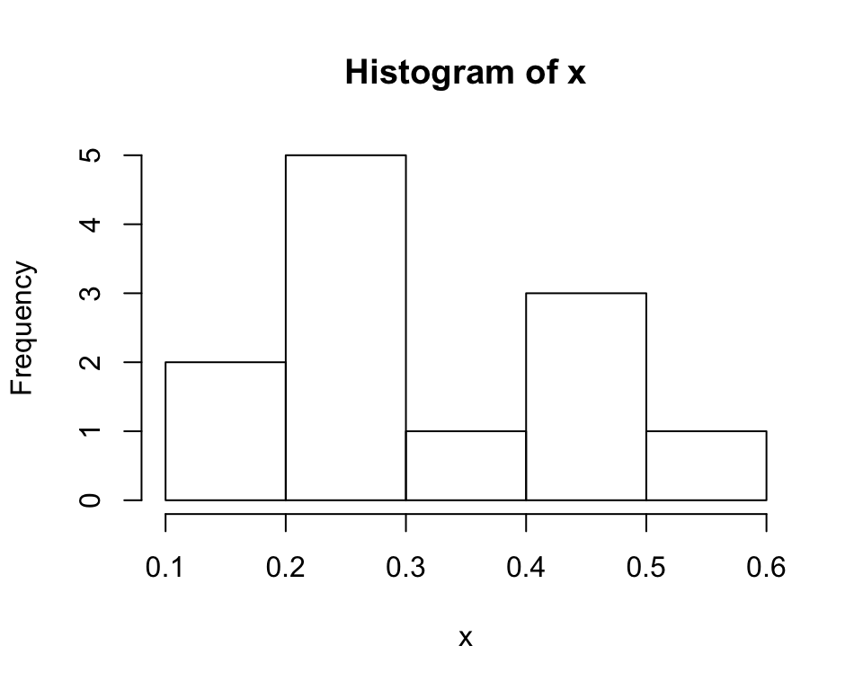

```r
x <- counts_mat['ENSMUSG00000081010',]
hist(x)
```

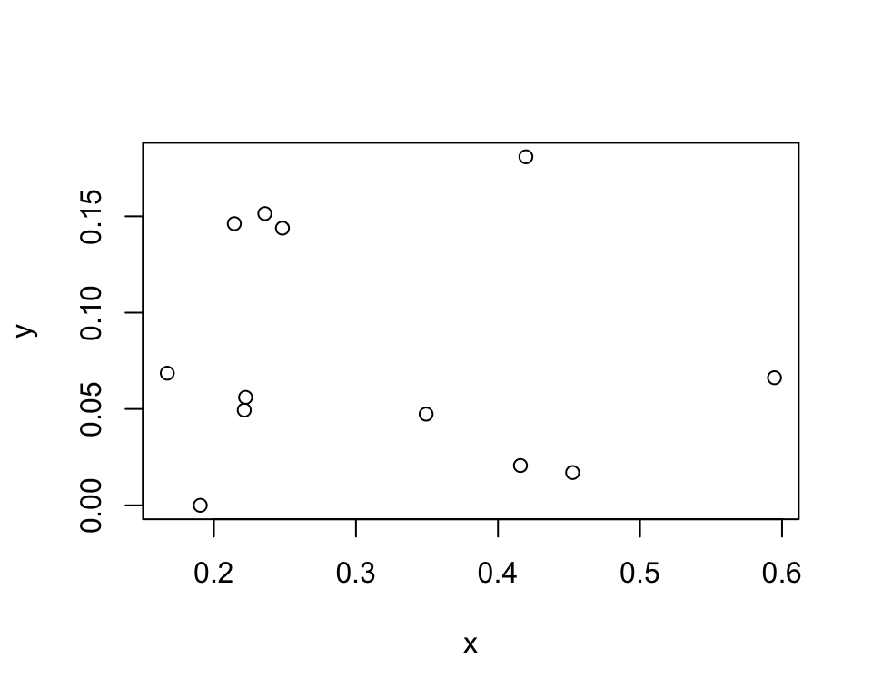

```r
y <- counts_mat['ENSMUSG00000000037',]
plot(x,y)
```

## Subsetting lists

```r
people <- list(
  Allice = list(age = 20, height = 50, school = 'MIT'),
  Bob = list(age = 10, height = 30, school = 'Harvard'),
  Charlie = list(age = 40, height = 60, school = 'BU'),
  Frank = c(age = 10, height = 2)
  )
```

- To select a specific element from the list use ‘double brackets’

```r
people[[2]]
```

```
## $age
## [1] 10
##
## $height
## [1] 30
##
## $school
## [1] "Harvard"
```

## Subsetting lists

- With lists it’s especially useful to access elements by name

```r
people[['Bob']]
```

```
## $age
## [1] 10
##
## $height
## [1] 30
##
## $school
## [1] "Harvard"
```

- Another (equivalent) way is to use the `$` symbol. This is nice because it works with ‘tab-complete’

```r
people$Bob
```

## Nested indexing of lists

- You can use multiple indices to pull out specific elements nested within a list

```r
people[['Allice']][['school']]
```

```
## [1] "MIT"
```

- Using `$` makes it much easier to read

```r
people$Allice$height
```

```
## [1] 50
```

**Practice**

## Creating dataframes

```r
species <- c("ecoli", "human", "corn")
glengths <- c(4.6, 3000, 50000)
```

- Create a tibble (dataframe, table) using `tibble()` function.
- Input as many columns as you want (must have same length)

```r
df <- tibble(species, glengths)
df
```

```
## # A tibble: 3 x 2
##   species glengths
##   <chr>      <dbl>
## 1 ecoli        4.6
## 2 human     3000
## 3 corn     50000
```

- Can name the columns

```r
df <- tibble(animal_species = species, genome_lengths = glengths)
df
```

```
## # A tibble: 3 x 2
##   animal_species genome_lengths
##   <chr>                   <dbl>
## 1 ecoli                     4.6
## 2 human                  3000
## 3 corn                  50000
```

## Quick note on new/old ways

- `data.frame()` is the old way, gives a similar table

```r
df <- data.frame(species = species, glengths = glengths)
df
```

```
##   species glengths
## 1   ecoli      4.6
## 2   human   3000.0
## 3    corn  50000.0
```

- But it makes strings into ‘factors’, and has some other subtle differences.
- Use `tibble()`

## Subsetting dataframes (columns)

- You can access a column from a dataframe as if it were a list of vectors (it is):

```r
df$species
```

```
## [1] "ecoli" "human" "corn"
```

```r
df[['species']]
```

```
## [1] "ecoli" "human" "corn"
```

## Subsetting dataframes (rows)

- You can access rows and columns of dataframes like matrix indexing

```r
df[2,]
```

```
## # A tibble: 1 x 2
##   species glengths
##   <chr>      <dbl>
## 1 human       3000
```

```r
df[2:3, 'glengths']
```

```
## # A tibble: 2 x 1
##   glengths
##      <dbl>
## 1     3000
## 2    50000
```

## Saving data to a file

- Just like the inverse of reading data
- `write_csv` to save tables
- `write.csv` to save matrices
- Use `here` function to specify the path to save the file

```r
write_csv(df, here::here('results', 'my_dataframe.csv'))
```

**Practice**